# Assignment 2

### Student Name: Isabella Blanka Zenkl

### Student #: 25550012

```python
import pandas as pd
import numpy as np
import matplotlib.pyplot as plt

from sklearn.linear_model import LogisticRegression
from sklearn.model_selection import train_test_split
from sklearn.preprocessing import MinMaxScaler
from sklearn.metrics import accuracy_score
```

## Question 1: Logistic Regression

f(x) = -7 + 0.05(x1) + 1(x2)

### a)

```python
x1 = 40
x2 = 3.5
log_odds = -7 + 0.05 * x1 + 1 * x2

print(f"the log odds are {log_odds}")
```

```
the log odds are -1.5
```

```python
p = 1 / (1 + np.exp(-log_odds))
print(f"ANSWER a) the probability is {round(p,2)}")
```

```
ANSWER a) the probability is 0.18
```

### b)

0 = -7 + 0.05 * x1 + 1 * 3.5

7 = 0.05x1 + 3.5

3.5 = 0.05x1

70 = x1

ANSWER b) The student would need to study for 70 hours to get a 50% chance of getting an A in the class given that their GPA is 3.5

### c)

```python
print(f"ANSWER c) the log odds are {log_odds}")
print(f"the probability is {round(p,2)}")
```

```
ANSWER c) the log odds are -1.5
the probability is 0.18
```

log_odds = ln(p/1-p)

log_odds = ln(0.18/1-0.18)

Thus:

```python
odds_ratio = 0.18/(1-0.18)
print(f"ANSWER c) The odds ratio is {round(odds_ratio,2)}")
```

```
ANSWER c) The odds ratio is 0.22
```

ANSWER c) the odds ratio means that the odds for getting an A are about 0.22 to 1. This means that for every 1 student that gets an A, around 4.5 students do not.

### d)

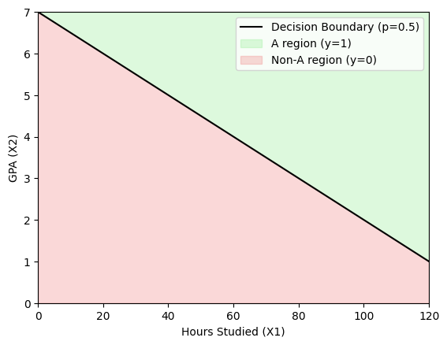

```python
# make X1 range (hours studied)
X1 = np.linspace(0, 120, 100)

# decision boundary line (where p = 0.5 -> f(x)=0)
X2 = 7 - 0.05 * X1

# plot
plt.plot(X1, X2, 'k', label='Decision Boundary (p=0.5)')

# fill the two regions
plt.fill_between(X1, X2, 7, color='lightgreen', alpha=0.3, label='A region (y=1)')
plt.fill_between(X1, 0, X2, color='lightcoral', alpha=0.3, label='Non-A region (y=0)')

plt.xlabel('Hours Studied (X1)')
plt.ylabel('GPA (X2)')
plt.xlim(0, 120)
plt.ylim(0, 7)
plt.legend()
plt.show()
```

## Question 2: Odds-ratio and Probability

### a)

ANSWER a) The odds ratio is p/(1-p) so 0.2/0.8 = 0.25. This means that for every 1 time she defaults, you’d expect 4 times she doesn’t.

### b)

p/(1-p) = 0.4

p = 0.4(1-p)

p = 0.4 - 0.4p

1.4p = 0.4

p = 0.29

ANSWER b) Thus, the probability that this person will default on their credit card payment is 0.29

## Question 3: Support Vector Machine

### a)

ANSWER a) The following instances are support vectors in the model: 1, 2, 7, 8, 9, 11, 12

### b)

ANSWER b) No, only movement of support vectors affects the model. Number 4 is not a support vector, thus its movement will not affect the model... Unless it moves enough to be **on** or **in** the decision margin, in which case it would **become** a support vector and then its movement would affect the model.

### c)

ANSWER c) the instances that will bring **hinge loss** but are **NOT missclassified** are: 1, 2, 7, 8, 9. Thus the number of instances in this condition is **5**.

### d)

ANSWER d) the instances that **will be missclassified** are: 11 and 12. Thus the number of instances in this condition is 2.

## Question 4: Logistic Regression

### a)

```python
smoking = pd.read_csv('smoking.csv', sep = ',') #ANSWER a)
display(smoking.shape, smoking.columns, smoking.head())
```

```
(10000, 10)
```

```
Index(['smoker', 'smkban', 'age', 'hsdrop', 'hsgrad', 'colsome', 'colgrad',
       'black', 'hispanic', 'female'],
      dtype='object')
```

|  | smoker | smkban | age | hsdrop | hsgrad | colsome | colgrad | black | hispanic | female |
| --- | --- | --- | --- | --- | --- | --- | --- | --- | --- | --- |
| 0 | 1 | 0 | 49 | 0 | 1 | 0 | 0 | 0 | 0 | 0 |
| 1 | 1 | 0 | 52 | 0 | 0 | 1 | 0 | 0 | 0 | 0 |
| 2 | 0 | 0 | 15 | 0 | 0 | 1 | 0 | 0 | 0 | 1 |
| 3 | 1 | 0 | 37 | 0 | 1 | 0 | 0 | 0 | 0 | 0 |
| 4 | 0 | 1 | 24 | 0 | 0 | 1 | 0 | 0 | 0 | 1 |

```python
print(smoking['smoker'].value_counts())

print()

print(f"ANSWER a) There are {smoking.shape[0]} instances")

print(f"ANSWER a) of which {smoking['smoker'].value_counts()[1]} are smokers and {smoking['smoker'].value_counts()[0]} are non-smokers")
```

```
smoker
0    7577
1    2423
Name: count, dtype: int64

ANSWER a) There are 10000 instances
ANSWER a) of which 2423 are smokers and 7577 are non-smokers
```

### b)

```python
#ANSWER b) select relevant features and target
X = smoking[['smkban', 'female', 'age']] # Q: drop first and then scale or scale then drop? in the class one we scale then drop...
y = smoking['smoker']

#ANSWER b) split the data into train (80%) and test (20%) set, and set random_state = 2025
X_train, X_test, y_train, y_test = train_test_split(X, y, test_size=0.2, random_state=2025)
display(X_train.shape, X_test.shape, y_train.shape, y_test.shape)
```

```
(8000, 3)
```

```
(2000, 3)
```

```
(8000,)
```

```
(2000,)
```

```python
#ANSWER b) Scale the features with MinMaxScaler

scaler = MinMaxScaler()

X_train_scaled = scaler.fit_transform(X_train)   # combine train and transform together

X_test_scaled  = scaler.transform(X_test)        # apply the scaler on test
```

### c)

```python
#add column names back by converting them as a dataframes with column names
X_train_scaled = pd.DataFrame(X_train_scaled, columns = X_train.columns)

X_test_scaled = pd.DataFrame(X_test_scaled, columns = X_train.columns)

display(X_train_scaled.head(), X_test_scaled.head())
```

|  | smkban | female | age |
| --- | --- | --- | --- |
| 0 | 0.0 | 1.0 | 0.361111 |
| 1 | 0.0 | 1.0 | 0.305556 |
| 2 | 1.0 | 0.0 | 0.527778 |
| 3 | 1.0 | 1.0 | 0.250000 |
| 4 | 0.0 | 1.0 | 0.222222 |

|  | smkban | female | age |
| --- | --- | --- | --- |
| 0 | 0.0 | 0.0 | 0.166667 |
| 1 | 0.0 | 1.0 | 0.361111 |
| 2 | 0.0 | 1.0 | 0.416667 |
| 3 | 0.0 | 1.0 | 0.402778 |
| 4 | 1.0 | 1.0 | 0.500000 |

```python
#ANSWER c) train a logistic regression model and display all parameter values

m1 = LogisticRegression().fit(X_train_scaled, y_train)

intercept = round(m1.intercept_[0],2)
w1 = round(m1.coef_[0][0],2)
w2 = round(m1.coef_[0][1],2)
w3 = round(m1.coef_[0][2],2)
column_names = m1.feature_names_in_

display(f"ANSWER c) f(x) = {intercept} + {w1} * {column_names[0]} + {w2} * {column_names[1]} + {w3} * {column_names[2]}")

display("ANSWER c) this means that all else kept equal, for every: 1 point increase in smkban, the log-odds of smoker (y=1) decreases by 1.5, same for the other parameters with their corresponding coefficients")
```

```
'ANSWER c) f(x) = -2.03 + -1.5 * smkban + -0.69 * female + 5.12 * age'
```

```
'ANSWER c) this means that all else kept equal, for every: 1 point increase in smkban, the log-odds of smoker (y=1) decreases by 1.5, same for the other parameters with their corresponding coefficients'
```

### d)

```python
#ANSWER d) check the model accuracy on both the train and test set

#train data:
train_pred1 = m1.predict(X_train_scaled)
print(f"ANSWER d) the accuracy on the training data is {round(accuracy_score(train_pred1, y_train),2)}")

#test data:
test_pred1 = m1.predict(X_test_scaled)
print(f"ANSWER d) the accuracy on the test data is {round(accuracy_score(test_pred1, y_test),2)}")
```

```
ANSWER d) the accuracy on the training data is 0.79
ANSWER d) the accuracy on the test data is 0.77
```

### e)

```python
person_values = [[0, 0, 48]] # male, no smoking ban, 48 years old

#make person dataframe to put into MinMaxScaler
person = pd.DataFrame(person_values, columns=X_train.columns)

# scale using the same scaler
person_scaled = scaler.transform(person)

#add back column names by making into a data frame
person_scaled = pd.DataFrame(person_scaled, columns=X_train.columns)

# make prediction
pred_class = m1.predict(person_scaled)
pred_prob = m1.predict_proba(person_scaled)

print(f"ANSWER e) Predicted class (0= non-smoker, 1= smoker): {pred_class[0]}")
print(f"ANSWER e) Probability of smoking (y=1): {round(pred_prob[0][1],2)}")
```

```
ANSWER e) Predicted class (0= non-smoker, 1= smoker): 1
ANSWER e) Probability of smoking (y=1): 0.6
```

### Extra for fun! (my probability of being a smoker)

```python
my_values = [[1, 0, 25]] # female, no smoking ban, 25 years old

#make person dataframe to put into MinMaxScaler
me = pd.DataFrame(my_values, columns=X_train.columns)

# scale using the same scaler
me_scaled = scaler.transform(me)

#add back column names by making into a data frame
me_scaled = pd.DataFrame(me_scaled, columns=X_train.columns)

# make prediction
pred_class = m1.predict(me_scaled)
pred_prob = m1.predict_proba(me_scaled)

print(f"My predicted class (0= non-smoker, 1= smoker): {pred_class[0]}")
print(f"My probability of smoking (y=1): {round(pred_prob[0][1],2)}")
```

```
My predicted class (0= non-smoker, 1= smoker): 0
My probability of smoking (y=1): 0.06
```